## Lobbying for Loopholes

#### [Marc Vermette](https://ca.linkedin.com/in/marc-vermette)

A Canadian investigative journalist, [Carl Meyer](https://twitter.com/ottawacarl), spent time looking into energy policy, and the lobbying which often accompanies decisions made within this space.

One of their [findings](https://twitter.com/ottawacarl/status/1539603534953562113?cxt=HHwWgoC-vcDQ4t0qAAAA) were changes made to a specific decision. Rather than imposing [strict limits on the pollution created](https://www.canada.ca/en/environment-climate-change/news/2022/03/government-of-canada-launches-next-steps-towards-deeper-methane-reductions-from-oil-and-gas.html) by the industry’s older, less efficient, and higher emitting facilities, companies would instead be allowed to meet emission targets based on the average emission levels of a select group of their facilities.

This loophole continues to allow companies to more easily meet emissions and climate targets for a type of high-emission heavy oil processes.

This change was implemented into the regulations, despite officials saying that it would likely encourage companies and individuals to “game” the system, making compliance and actual change harder to enforce.

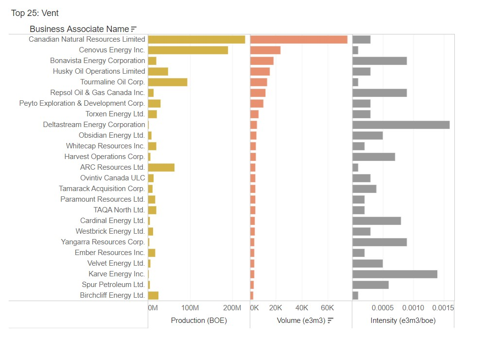

Canadian Oil Production Visualized, [graph credits to Carl Meyer](https://twitter.com/ottawacarl/status/1539610256162127872)

[Original Article](https://thenarwhal.ca/alberta-climate-methane-cnrl/)